# Standardising a realistic logbook: two worked examples

Henning Winker FAO Fisheries and Aquaculture Division, Assessment and Management Team (NFIFM) henning.winker@fao.org

This vignette takes a realistic multispecies logbook from the raw records to standardised abundance indices for two species. The logbook is simulated with `simulate_logbook()`, so it has the problems of real data (trips that combine two tactics, coarse and missing positions, rounding, under-reported bycatch, a species recorded under two names, fleet turnover, a closure), but the true tactics and the true biomass trends are known and every step can be checked.

- **Part 1** prepares the logbook. These steps are the same for every species: format the data, explore the fleet, choose the species set, look at nominal CPUE and catch composition, and derive targeting covariates.
- **Part 2** standardises **blackspot seabream**, a deep-reef demersal species caught by the reef handline.
- **Part 3** standardises **dolphinfish**, a seasonal pelagic migrant caught by trolling.

| Step | Question | Functions | Part |
| --- | --- | --- | --- |
| 1. Format | Which column is what? One row per operation? | `cpue_data()`, `subset()` | 1 |
| 2. Fleet | Who fished when? Specialists or mixed vessels? | `plot_fleet()`, `vessel_summary()`, `plot_vessel_profile()`, `select_vessels()` | 1 |
| 3. Species | Which species carry the targeting signal? | `species_curve()`, `plot_species_curve()`, `select_species()` | 1 |
| 4. Nominal CPUE | What do the raw data say? | `plot_nominal()`, `plot_composition()`, `plot_cpue_map()` | 1 |
| 5. Subsetting | Which trips could catch the species? | `select_tactics()`, `stephens_maccall()` | 2, 3 |
| 6. Targeting covariates | How did fishing tactics change? | `add_targeting()`, `plot_oc()`, `plot_biplot()`, `tactic_table()`, `plot_targeting()` | 1, 2, 3 |
| 7. Models | Base, spatial, Cluster, DPC, vessel effects, season | `fit_cpue()` | 2, 3 |
| 8. Diagnostics | Which terms matter? Does the error distribution fit? | `cpue_diagnostics()`, `plot_index()`, `plot_step()`, `plot_influence()`, `plot_residuals()`, `ppc_cpue()`, `plot_effects()`, `plot_vessel_effects()` | 2, 3 |
| 9. Index | The index for the assessment | `cpue_index()`, `export_index()` | 2, 3 |

How the simulator works is described in *Setting up the logbook simulator: a user guide*; the general guidelines in *Analysing real catch and effort data: a step-by-step guide*.

# The logbook

```r
sim <- simulate_logbook(seed = 1)
sp_tab <- sim$settings$species
knitr::kable(sp_tab[, c("species", "group", "habitat", "depth_mu", "price")],
             row.names = FALSE)
```

| species | group | habitat | depth_mu | price |
| --- | --- | --- | --- | --- |
| Dentex dentex | demersal | shallow reef | 60 | 12 |
| Pagellus erythrinus | demersal | shallow sediment | 50 | 8 |
| Pagellus bogaraveo | demersal | deep reef | 350 | 15 |
| Merluccius merluccius | demersal | deep sediment | 400 | 5 |
| Conger conger | demersal | reef, all depths | 150 | 3 |
| Phycis blennoides | demersal | deep, mixed | 500 | 2 |
| Thunnus alalunga | pelagic | offshore | 700 | 6 |
| Coryphaena hippurus | pelagic | warm, offshore | 300 | 7 |
| Seriola dumerili | pelagic | coastal, reef-associated | 100 | 9 |
| Scomber colias | pelagic | coastal | 60 | 2 |

Prices favour demersal species in 2000-2007 and pelagic species in 2008-2015; from 2016 prices are neutral, the bottom longline is banned deeper than 300 m and effort is cut. Nominal CPUE (orange) departs from the true biomass (black) in different ways for each species:

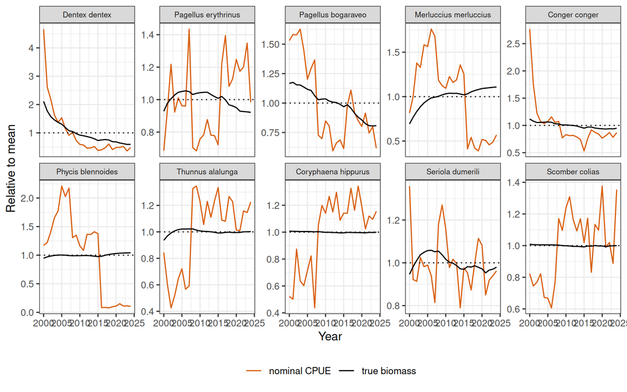

```r
sim$Plots$cpue
```

This is what an analyst receives; the tactic is not in the logbook:

```r
head(sim$logbook, 8)
```

```
##   trip year month vessel hours  lon   lat               species    kg
## 1    1 2000     1    V04   7.3 3.85 36.85         Dentex dentex 256.5
## 2    1 2000     1    V04   7.3 3.85 36.85        Scomber colias  23.5
## 3    1 2000     1    V04   7.3 3.85 36.85      Seriola dumerili  14.0
## 4    2 2000     1    V12   9.7 3.85 36.85         Conger conger  83.5
## 5    2 2000     1    V12   9.7 3.85 36.85 Merluccius merluccius  24.5
## 6    2 2000     1    V12   9.7 3.85 36.85        Scomber colias   3.5
## 7    2 2000     1    V12   9.7 3.85 36.85      Seriola dumerili   9.5
## 8    3 2000     1    V10   7.8 4.85 39.35    Pagellus bogaraveo  30.5
```

# Part 1. Preparing the logbook

## Step 1. Format the data

`cpue_data()` turns the logbook (long format: one row per trip and species) into one row per operation with one column per species, merges species synonyms, and starts a processing log.

```r
x <- cpue_data(sim$logbook, year = "year", species = "species", catch = "kg",
               effort = "hours", id = "trip", vessel = "vessel",
               lon = "lon", lat = "lat", covariates = "month",
               synonyms = c("Blackspot seabream" = "Pagellus bogaraveo"))
x <- subset(x, !is.na(lon), note = "positions reported")
x
```

```
## <cpue_data> 19218 operations, 10 species, years 2000 - 2024
##   vessels: 40
##   effort: hours
##   position: lon / lat
##   covariates: month
##   main species: Scomber colias, Merluccius merluccius, Thunnus alalunga, Pagellus erythrinus, Pagellus bogaraveo ...
## Processing log:
##                 step operations                             note
##  input (long format)      19574        46775 records, 10 species
##               subset      19218 positions reported (356 removed)
```

> **Guidelines**
> - Define the **operation**: the unit at which catch and effort are recorded (set, haul, day or trip). Here it is the trip, and about a fifth of the trips combine sets of two tactics; their catch composition is a mixture.
> - Choose an **effort** measure that scales catch (here hours fished).
> - Merge **synonyms** first (here blackspot seabream recorded under its common name in some trips); they change the species set.
> - Every selection with `subset()` is written to the log (`x$log`).

## Step 2. Explore the fleet

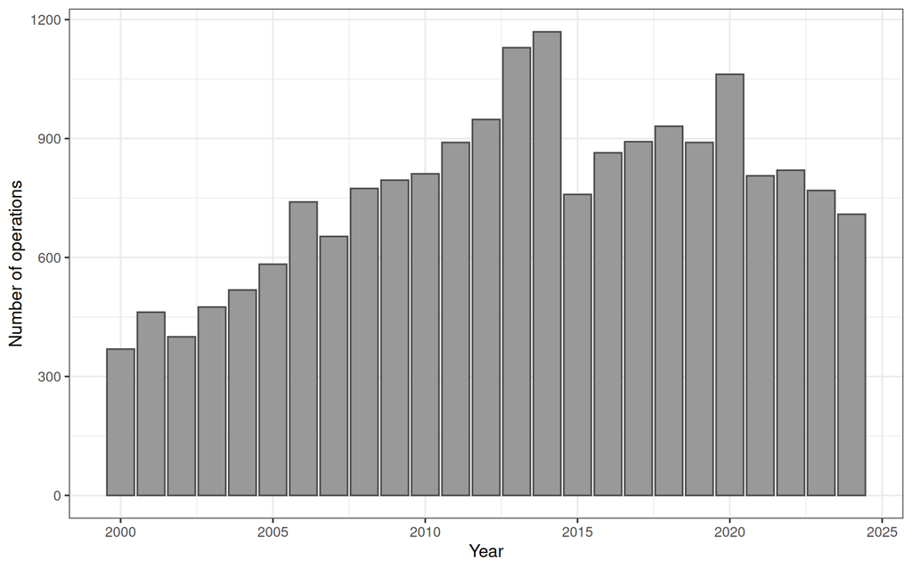

```r
fl <- plot_fleet(x)
fl$records
```

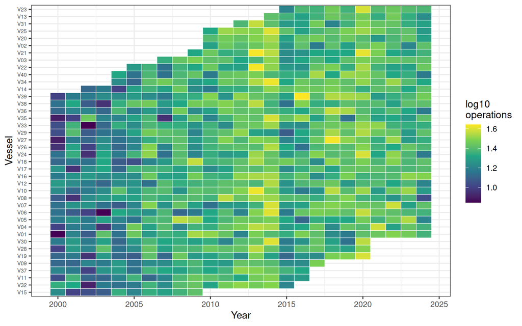

```r
fl$vessels
```

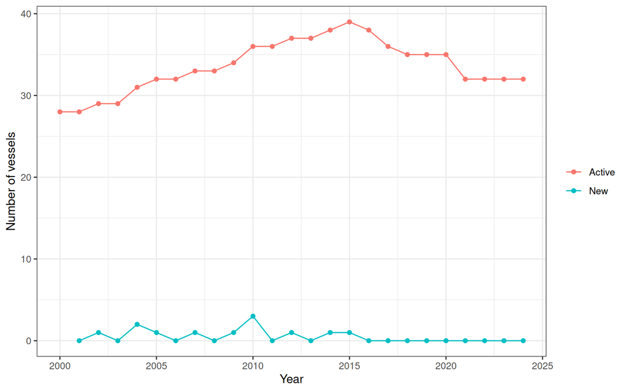

```r
fl$vessel_years
```

Vessels enter and leave over the years. Each vessel’s catch profile shows how far the fleet is split into specialists:

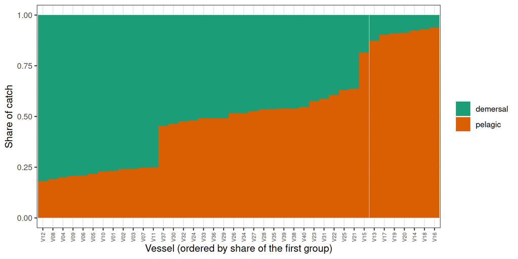

```r
groups <- list(demersal = sp_tab$species[sp_tab$group == "demersal"],
               pelagic = sp_tab$species[sp_tab$group == "pelagic"])
plot_vessel_profile(x, groups = groups)
```

```r
head(vessel_summary(x), 8)
```

```
##   vessel records years years_qualified first last
## 1    V10     599    25              25  2000 2024
## 2    V16     599    25              25  2000 2024
## 3    V39     587    25              25  2000 2024
## 4    V38     585    25              25  2000 2024
## 5    V18     581    25              25  2000 2024
## 6    V01     578    25              25  2000 2024
## 7    V27     576    25              25  2000 2024
## 8    V05     575    25              25  2000 2024
```

Since the data are simulated, we can label the vessels with their true type:

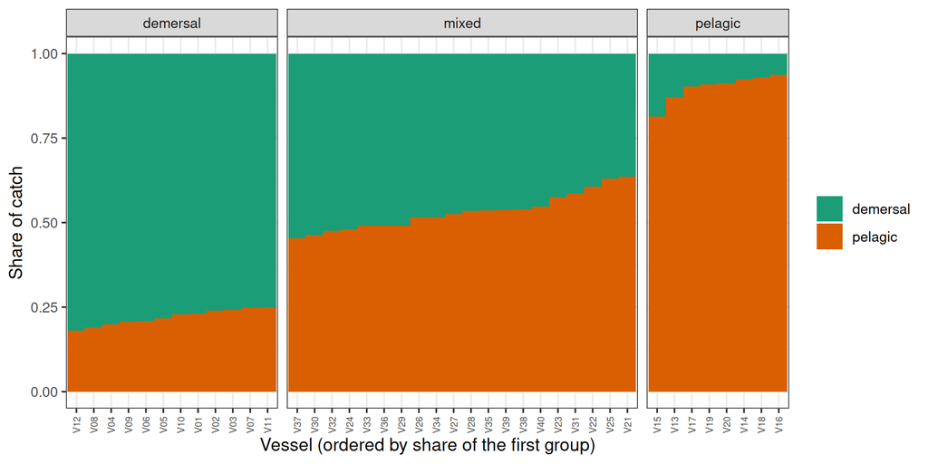

```r
type <- tapply(sim$trips$vessel_type, sprintf("V%02d", sim$trips$vessel),
               function(z) z[1])
plot_vessel_profile(x, groups = groups, by = type)
```

> **Guidelines**
> - Strong **fleet turnover** confounds vessel efficiency with year; random vessel effects help if vessels overlap in time.
> - **Specialists** (vessels at either end of the profile plot) target the same species throughout; their targeting is absorbed by a vessel effect. **Mixed vessels** switch tactics with prices; that is the targeting that the catch composition has to capture.
> - An **indicator fleet** (`select_vessels()`) keeps vessels that fished consistently, optionally with rules on the target species (`min_years_target`, `min_share_target`). Compare the index with and without the selection.

## Step 3. Choose the species set

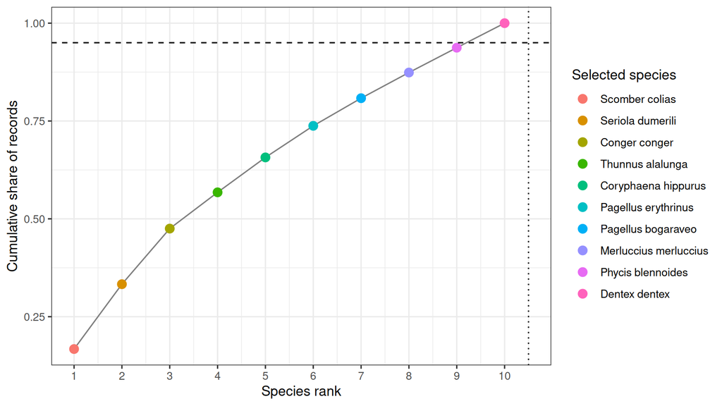

```r
plot_species_curve(x, threshold = 0.95)
```

```r
targets <- c("Pagellus bogaraveo", "Coryphaena hippurus")
x <- select_species(x, threshold = 0.95, keep = targets)
x$species_labels
```

```
##          Scomber.colias        Seriola.dumerili           Conger.conger
##        "Scomber colias"      "Seriola dumerili"         "Conger conger"
##        Thunnus.alalunga     Coryphaena.hippurus     Pagellus.erythrinus
##      "Thunnus alalunga"   "Coryphaena hippurus"   "Pagellus erythrinus"
##      Pagellus.bogaraveo   Merluccius.merluccius       Phycis.blennoides
##    "Pagellus bogaraveo" "Merluccius merluccius"     "Phycis blennoides"
##           Dentex.dentex
##         "Dentex dentex"
```

```r
# the species groups that are still in the data, for the selections below
demersal <- intersect(groups$demersal, x$species_labels)
pelagic <- intersect(groups$pelagic, x$species_labels)
```

> **Guidelines**
> - Rank species by **occurrence** (default) and check by weight.
> - Always **keep the species of interest**, even if rare.
> - Species characteristic of other tactics are valuable even if not abundant: they let the PCA separate the tactics.

## Step 4. Nominal CPUE and catch composition

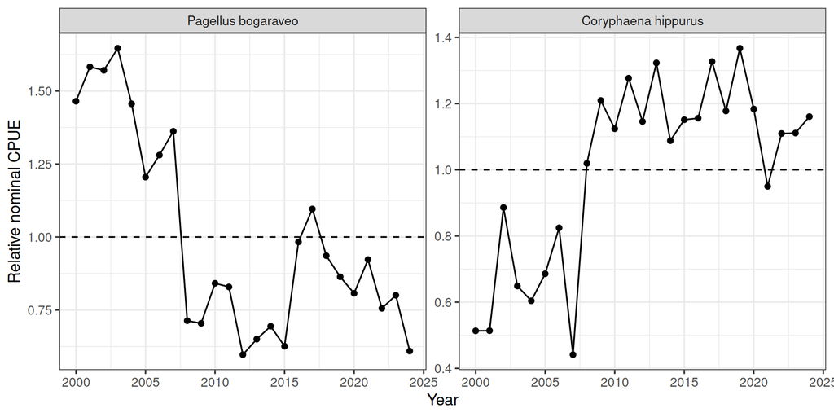

```r
nom <- plot_nominal(x, targets)
nom$index
```

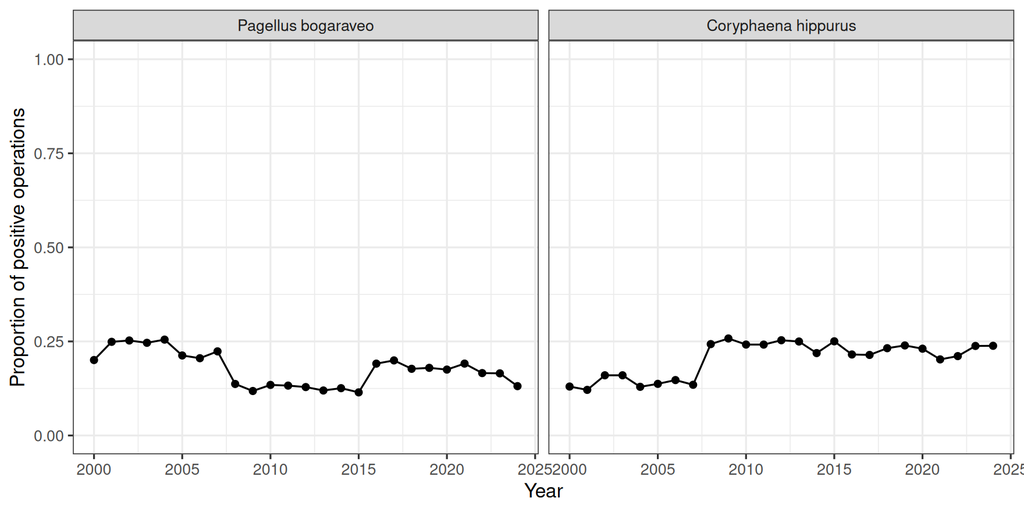

```r
nom$positive
```

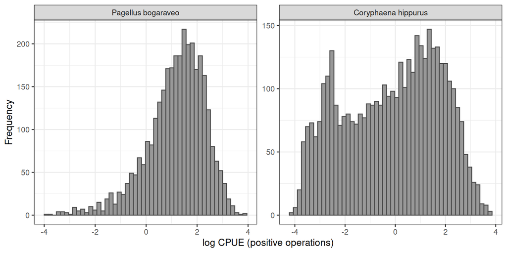

```r
nom$distribution
```

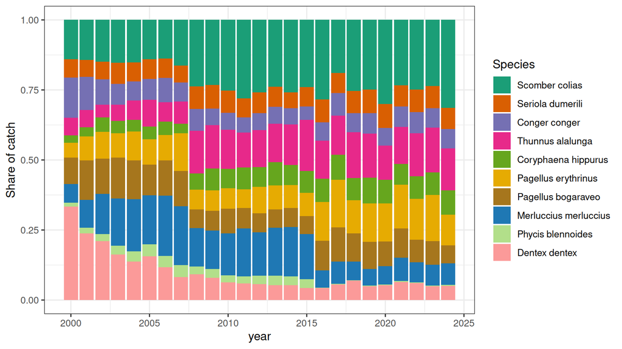

```r
plot_composition(x)
```

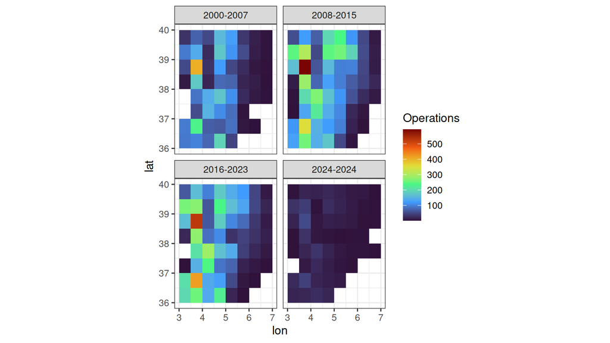

```r
plot_cpue_map(x, res = 0.5, by_period = 8)
```

Expect the catch composition to shift towards pelagic species in 2008-2015, at the same time as the prices: a first sign of targeting.

> **Guidelines**
> - The **share of positive trips** and the **distribution of positive CPUE** guide the choice of error distribution (Tweedie or delta).
> - Abrupt changes in composition at known changes in prices, regulations or gear point to targeting; gradual drifts may be abundance.

## Step 6. Targeting covariates for the whole fleet

```r
x <- add_targeting(x)
x$targeting$pca
```

```
## <cpue_pca> 19218 operations, 10 species, transform: fourth_root
##  PC eigenvalue share cumulative
##   1      2.192 0.219      0.219
##   2      1.707 0.171      0.390
##   3      1.340 0.134      0.524
##   4      1.108 0.111      0.635
##   5      1.056 0.106      0.740
##   6      0.792 0.079      0.820
##   7      0.569 0.057      0.876
##   8      0.530 0.053      0.929
## Optimal Coordinates: 3 non-trivial PC(s); 4 clusters by the npc + 1 rule
```

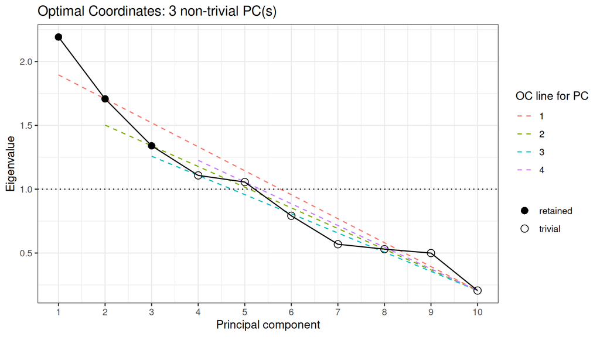

```r
plot_oc(x)
```

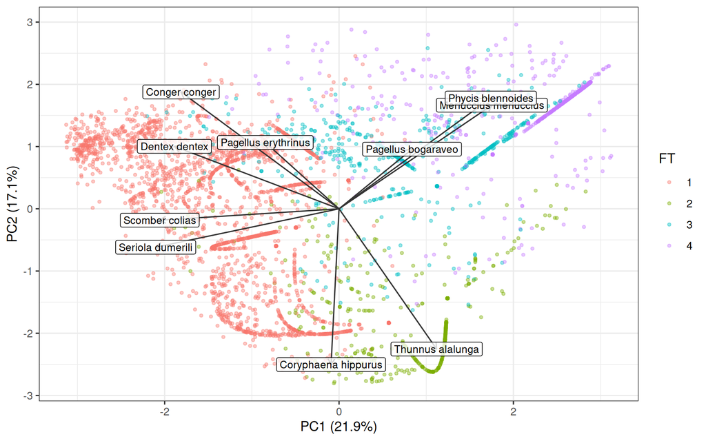

```r
plot_biplot(x)
```

```r
tactic_table(x)
```

```
##   FT operations share              dominant Scomber colias Seriola dumerili
## 1  1       9936 0.517        Scomber colias           38.3             11.6
## 2  2       3620 0.188      Thunnus alalunga            2.2              1.9
## 3  3       2849 0.148    Pagellus bogaraveo            1.6              1.6
## 4  4       2813 0.146 Merluccius merluccius            2.4              1.6
##   Conger conger Thunnus alalunga Coryphaena hippurus Pagellus erythrinus
## 1          10.8              0.7                 8.8                15.4
## 2           1.1             79.6                10.1                 2.2
## 3           3.2              0.7                 2.0                 9.0
## 4           2.4              1.0                 1.1                 2.6
##   Pagellus bogaraveo Merluccius merluccius Phycis blennoides Dentex dentex
## 1                0.5                   0.5               0.2          13.1
## 2                0.6                   0.7               0.4           1.2
## 3               75.5                   1.6               0.7           4.0
## 4                2.1                  73.2              10.9           2.7
```

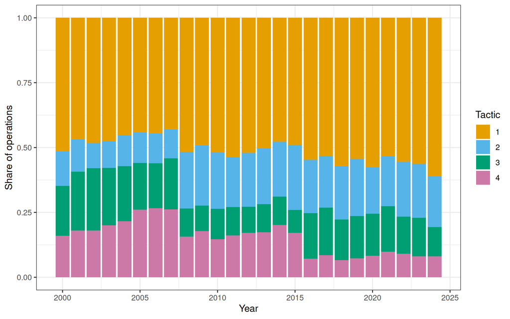

```r
pt <- plot_targeting(x, res = 0.5)
pt$time
```

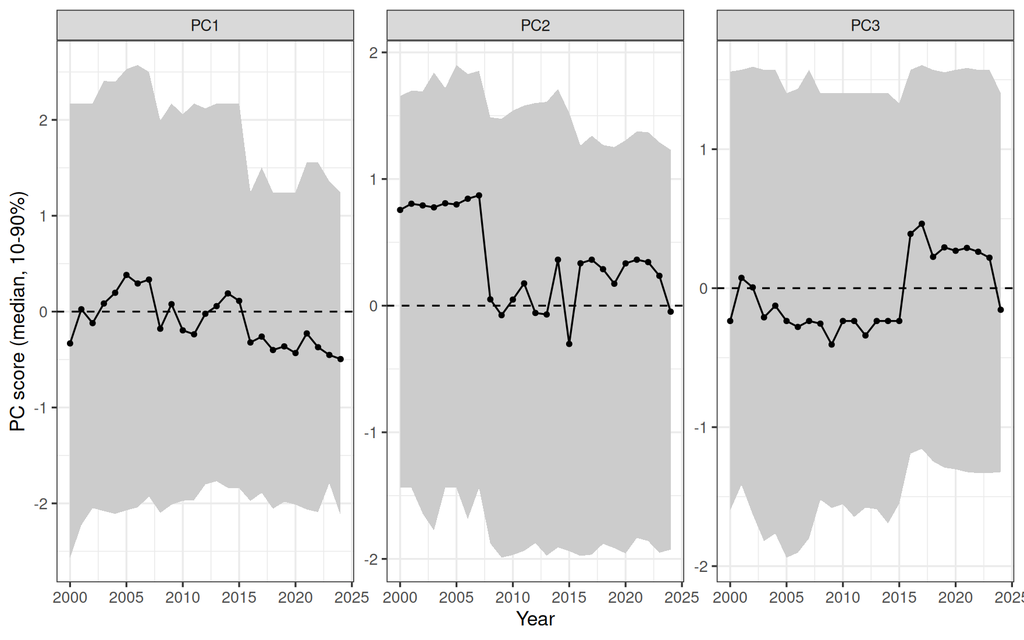

```r
pt$pcs_time
```

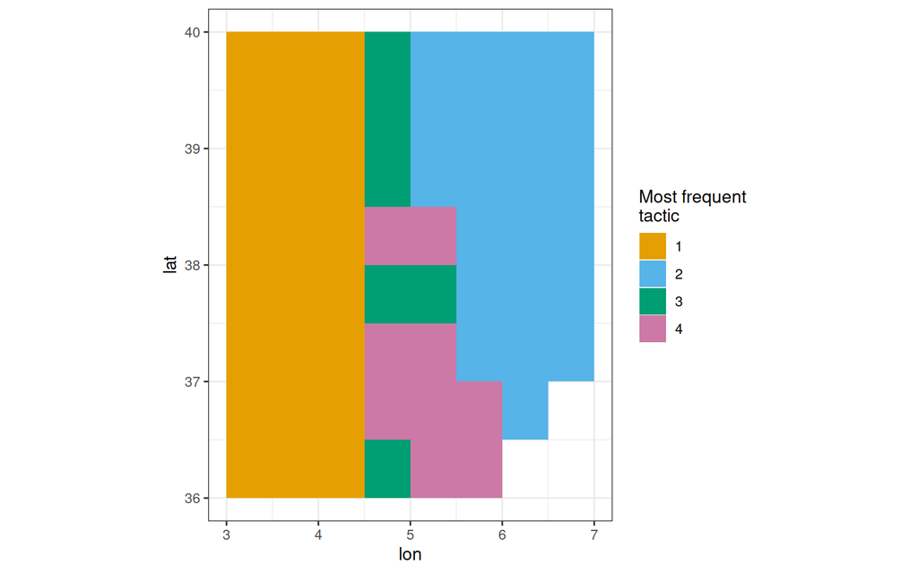

```r
pt$map_tactic
```

Check the clusters against the true tactic of each trip (not possible with real data):

```r
truth <- sim$trips[match(x$data$trip, sim$trips$trip), ]
round(prop.table(table(cluster = x$data$FT, true_tactic = truth$tactic), 1), 2)
```

```
##        true_tactic
## cluster Pelagic Reef Sediment
##       1    0.43 0.33     0.24
##       2    0.96 0.02     0.02
##       3    0.05 0.85     0.10
##       4    0.07 0.16     0.78
```

Across the whole fleet, the first axis is typically dominated by the contrast between pelagic and demersal trips (check the loadings). For a demersal species that contrast is mostly irrelevant: what matters is the targeting *within* the demersal trips. The worked examples therefore start by selecting the relevant tactics and recomputing the PCA.

> **Guidelines**
> - **Name the tactics** after their dominant species and check that they make sense to people who know the fishery.
> - **Number of PCs**: Optimal Coordinates test, not AIC; the composition is not independent of the response, so AIC selects too many PCs.
> - **Continuous or discrete?** PCs represent gradual changes and mixed trips; clusters assume distinct tactics.
> - Run `add_targeting()` again **after every selection**; PCs and clusters depend on the operations included (`select_tactics()` does this).

```r
# relative indices of several fits against the true biomass
compare_indices <- function(fits, true) {
  idx <- do.call(rbind, lapply(names(fits), function(n) {
    i <- cpue_index(fits[[n]]$fit, fits[[n]]$model)
    data.frame(year = i$year, relative = i$relative, lower = i$lower,
               upper = i$upper, index = n)
  }))
  true$true <- true$true / mean(true$true)
  ggplot(idx, aes(x = year, y = relative, colour = index, fill = index)) +
    geom_ribbon(aes(ymin = lower, ymax = upper), alpha = 0.12, colour = NA) +
    geom_line(linewidth = 0.8) +
    geom_line(data = true, aes(x = year, y = true), inherit.aes = FALSE,
              colour = "black", linewidth = 1.1) +
    geom_hline(yintercept = 1, linetype = 3) +
    labs(x = "Year", y = "Relative CPUE", colour = NULL, fill = NULL,
         subtitle = "black: true biomass") + theme_bw()
}
```

# Part 2. Worked example: blackspot seabream

Blackspot seabream (*Pagellus bogaraveo*) lives on deep reefs and is caught mainly by the reef handline. Its price is high in 2000-2007; during the pelagic boom (2008-2015) much of the fleet trolls for pelagic species instead, and in 2016 the closure moves effort.

```r
true_sbr <- logbook_truth(sim, "Pagellus bogaraveo")
```

## Step 5. Remove the trips that could not catch seabream

`select_tactics()` keeps the clusters whose catch is at least 50% demersal species and recomputes the PCA and clusters on the remaining trips.

```r
xd <- select_tactics(x, species = demersal, min_share = 0.5)
round(xd$targeting$previous$share, 2)    # demersal share of each previous cluster
```

```
##    1    2    3    4
## 0.41 0.06 0.94 0.94
```

```r
tail(xd$log, 3)
```

```
##             step operations
## 4  add targeting      19218
## 5 select tactics       5662
## 6  add targeting       5662
##                                                                                note
## 4                      3 PC(s) used (OC test: 3), 4 clusters (clara on composition)
## 5 clusters 3, 4 kept (clusters with >= 50% of catch from 6 species) (13556 removed)
## 6                      4 PC(s) used (OC test: 4), 5 clusters (clara on composition)
```

An alternative is the habitat-based selection of Stephens and MacCall (2004), which predicts the presence of seabream from the other species in each trip:

```r
sm <- stephens_maccall(x, target = "Pagellus bogaraveo")
sm
```

```
## <stephens_maccall> target: Pagellus bogaraveo
##   critical probability: 0.35
##   operations kept: 3208 of 19218 (17%)
##   target present in 63% of kept and 8% of dropped operations
```

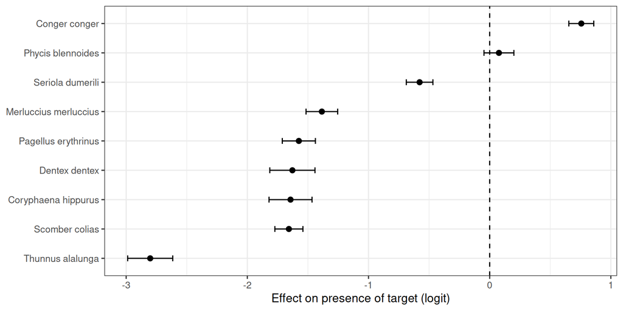

```r
pl <- plot_stephens_maccall(sm)
pl$coefficients
```

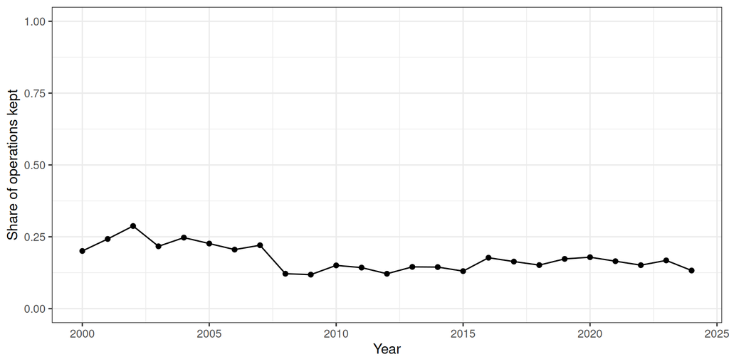

```r
pl$kept
```

## Step 6. Targeting covariates of the demersal trips

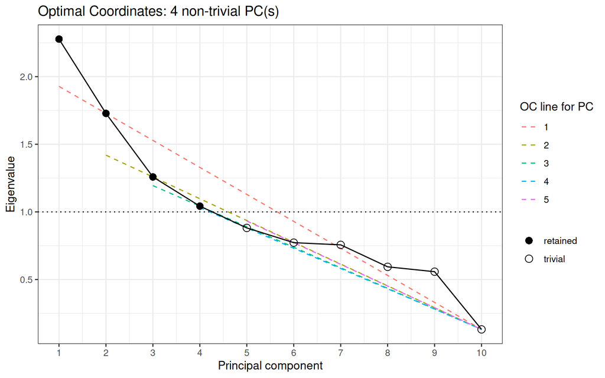

```r
plot_oc(xd)
```

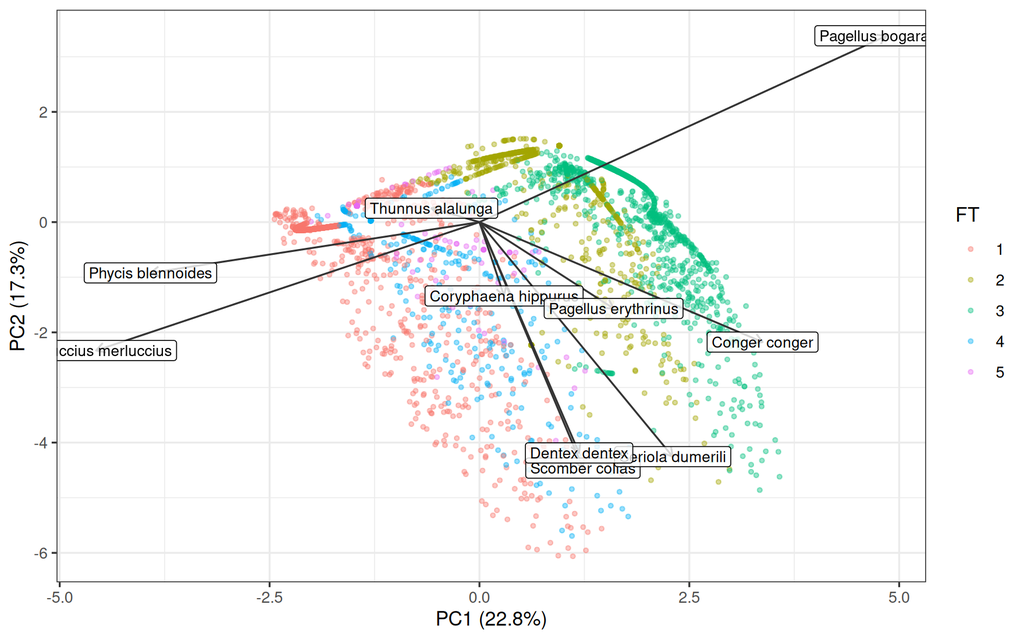

```r
plot_biplot(xd)
```

```r
tactic_table(xd)
```

```
##   FT operations share              dominant Scomber colias Seriola dumerili
## 1  1       1585 0.280 Merluccius merluccius            2.8              1.5
## 2  2       1581 0.279    Pagellus bogaraveo            2.2              1.3
## 3  3       1245 0.220    Pagellus bogaraveo            1.0              1.9
## 4  4        839 0.148 Merluccius merluccius            1.5              1.9
## 5  5        412 0.073     Phycis blennoides            0.0              1.1
##   Conger conger Thunnus alalunga Coryphaena hippurus Pagellus erythrinus
## 1           2.1              1.2                 0.9                 2.0
## 2           0.0              1.0                 2.9                 3.9
## 3           6.2              0.5                 1.1                14.0
## 4           2.9              0.6                 1.5                 3.5
## 5           2.6              0.0                 1.7                 7.4
##   Pagellus bogaraveo Merluccius merluccius Phycis blennoides Dentex dentex
## 1                2.4                  71.4              13.0           2.6
## 2               83.4                   1.6               0.7           3.0
## 3               68.8                   0.9               0.4           5.1
## 4                1.7                  83.5               0.1           2.8
## 5                3.7                   0.4              77.3           5.7
```

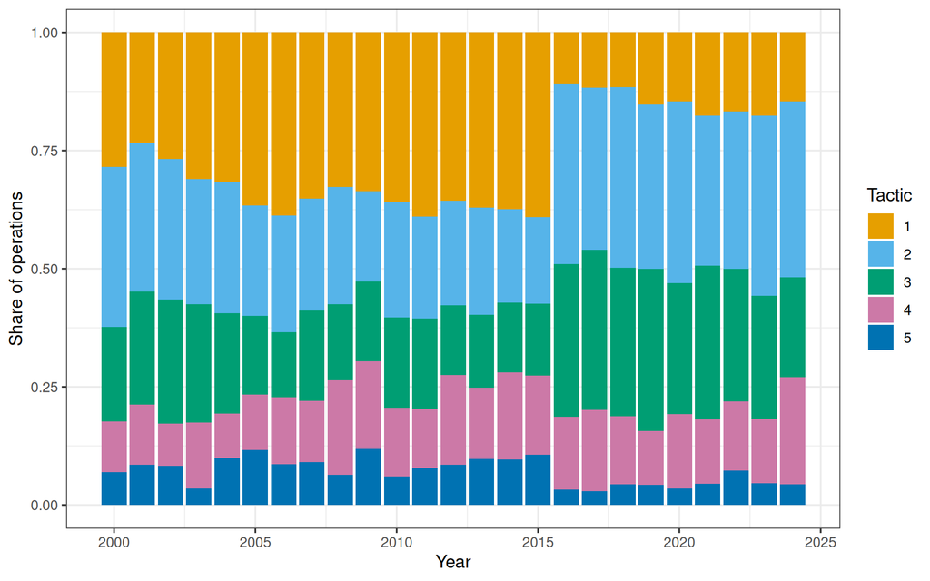

```r
pd <- plot_targeting(xd, res = 0.5)
pd$time
```

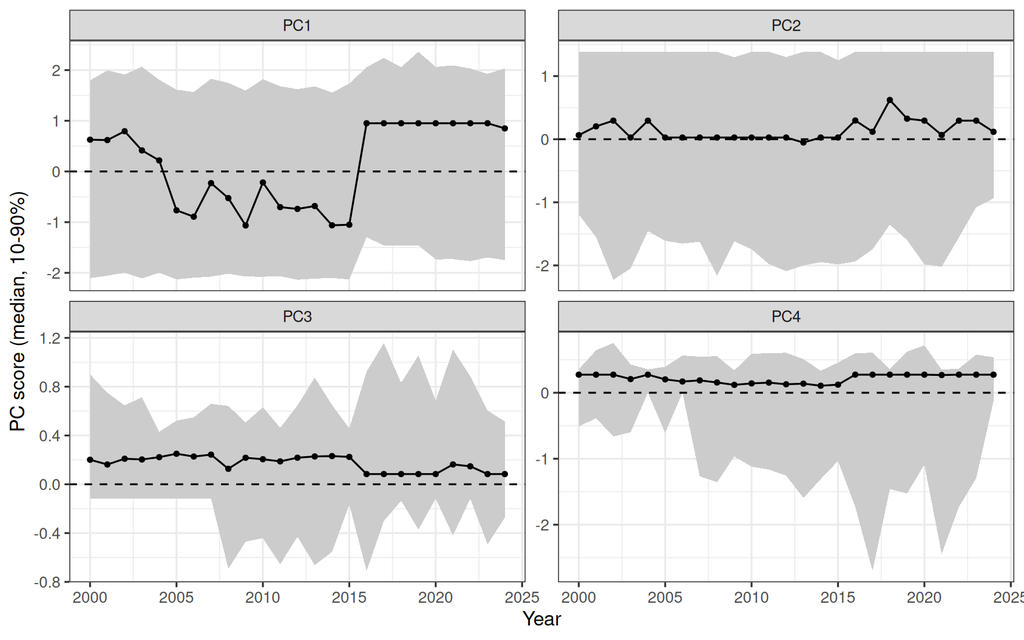

```r
pd$pcs_time
```

The new PCs describe the targeting within the demersal fishery, e.g. reef against sediment species and shallow against deep (check the loadings).

## Step 7. Fit the models

Terms are added in a meaningful order: year only, then space, then the targeting covariates; all models have a random vessel effect.

```r
fit_sbr <- fit_cpue(xd, species = "Pagellus bogaraveo",
                    models = c("Base", "Base+S", "Cluster+S", "DPC+S"),
                    vessel = TRUE, spatial_k = 40, engine = "bam")
fit_sbr
```

```
## <cpue_fit> Pagellus bogaraveo - tweedie with random vessel effects
##   operations: 5662 ; years: 2000 - 2024
##   index averaged over: FT (and positions in spatial models)
## Models:
##   Base         y ~ fyear + s(vessel_re, bs = "re")
##   Base+S       y ~ fyear + s(pos_x, pos_y, k = 40) + s(vessel_re, bs = "re")
##   Cluster+S    y ~ fyear + s(pos_x, pos_y, k = 40) + FT + s(vessel_re, bs = "re")
##   DPC+S        y ~ fyear + s(pos_x, pos_y, k = 40) + s(PC1, k = 4) + s(PC2, k = 4) + s(PC3, k = 4) + s(PC4, k = 4) + s(vessel_re, bs = "re")
```

## Step 8. Diagnostics

### Model comparison, indices and steps

```r
cpue_diagnostics(fit_sbr)
```

```
##       model component    n     AIC     BIC dev_explained   edf tweedie_p
## 1      Base      main 5662 24416.5 24804.9        0.0451  56.1     1.399
## 2    Base+S      main 5662 23215.8 23854.5        0.2321  93.5     1.358
## 3 Cluster+S      main 5662 19302.8 19934.7        0.6443  92.4     1.291
## 4     DPC+S      main 5662 18189.6 18889.8        0.7333 101.7     1.333
##   vessel_sd   dAIC
## 1     0.269 6226.9
## 2     0.266 5026.2
## 3     0.279 1113.2
## 4     0.286    0.0
```

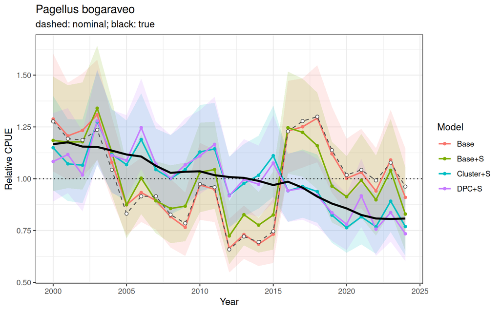

```r
plot_index(fit_sbr, true = true_sbr)
```

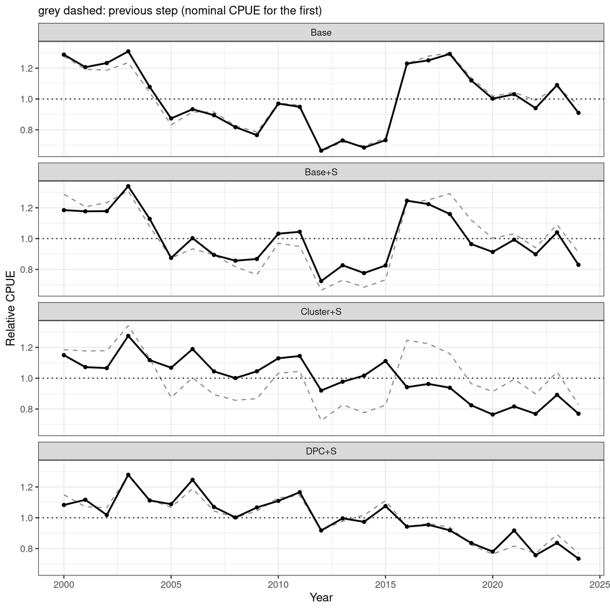

```r
plot_step(fit_sbr)
```

### Influence

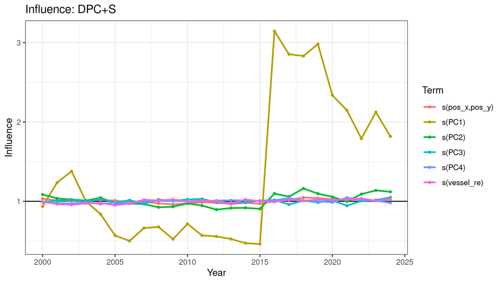

```r
plot_influence(fit_sbr, "DPC+S")
```

The influence of the targeting term should change over time where targeting changed, i.e. around the start and end of the pelagic boom (2008, 2016) and the closure (2016).

### Residuals

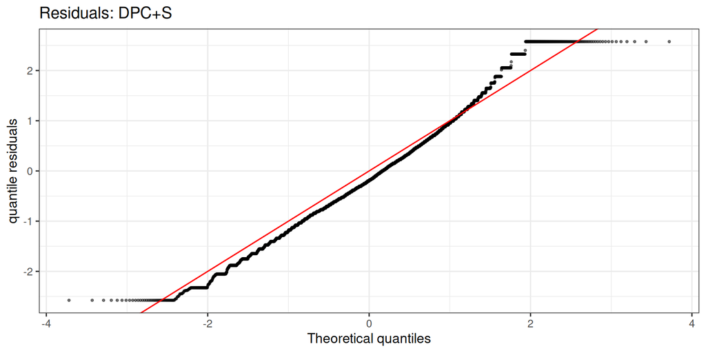

```r
res <- plot_residuals(fit_sbr, "DPC+S", by = "FT")
res$qq
```

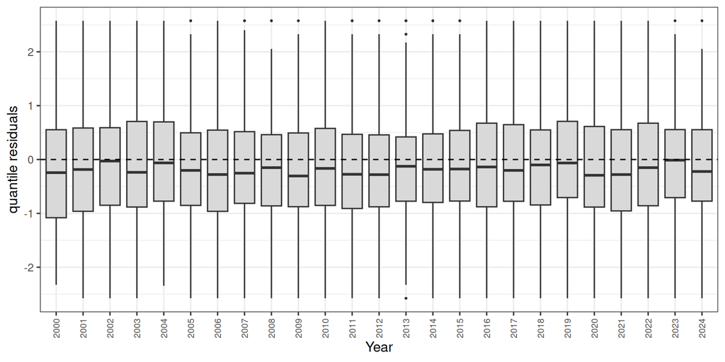

```r
res$year
```

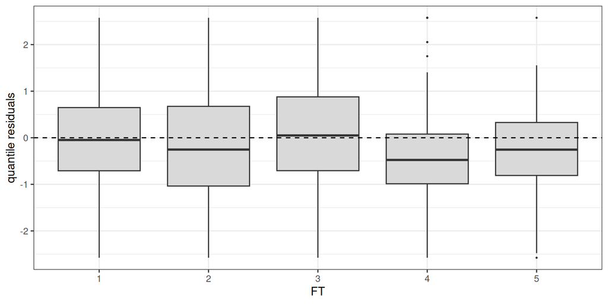

```r
res$by
```

### Predictive check of the error distribution

Residuals check each trip against its own predicted distribution. `ppc_cpue()` asks whether the fitted Tweedie distribution reproduces the data **as a whole**: it simulates 50 replicate data sets from each model (with parameter uncertainty) and compares the share of zeros, the upper tail and the histogram of CPUE with the observed data.

```r
pp_sbr <- ppc_cpue(fit_sbr, models = c("Base", "DPC+S"))
pp_sbr
```

```
## Predictive check: 50 replicates, with parameter uncertainty, tweedie
##
##  model  stat observed median  lower  upper tail_prob
##   Base zeros    0.473  0.355  0.341  0.373      0.00
##   Base  mean    2.950  2.950  2.850  3.090      0.50
##   Base   q90   12.000  9.820  9.530 10.200      0.00
##   Base   q99   24.300 18.700 17.400 19.700      0.00
##  DPC+S zeros    0.473  0.416  0.408  0.424      0.00
##  DPC+S  mean    2.950  2.990  2.890  3.080      0.80
##  DPC+S   q90   12.000 11.500 11.100 12.000      0.04
##  DPC+S   q99   24.300 20.200 19.000 21.400      0.00
```

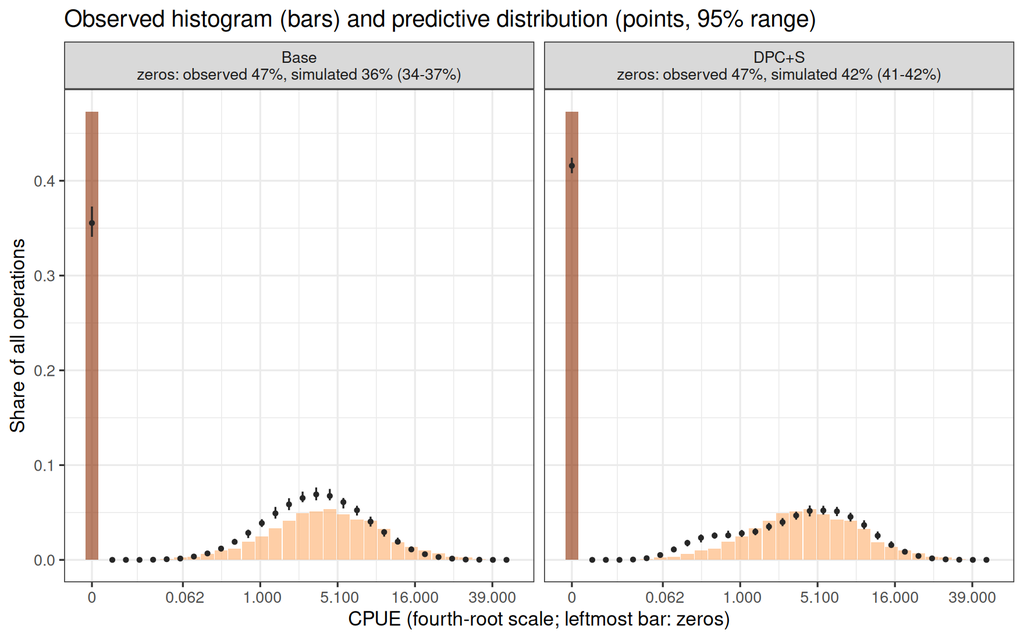

```r
pp_sbr$plots$distribution
```

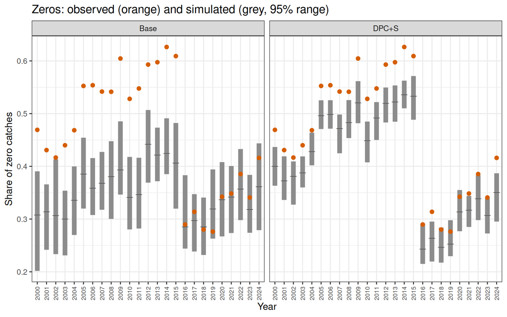

```r
pp_sbr$plots$zeros
```

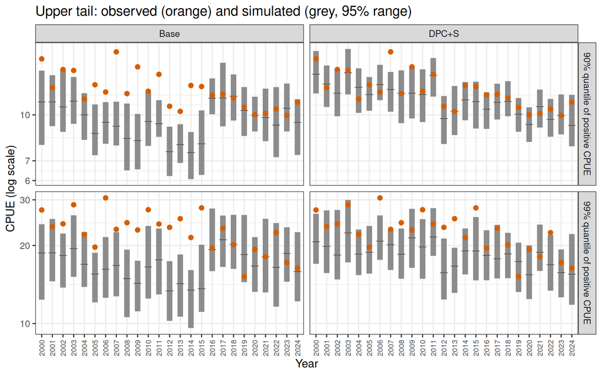

```r
pp_sbr$plots$tails
```

> **Guidelines: reading a predictive check**
> - **Histogram** (bars: observed, zeros leftmost; points: predicted with 95% ranges): bars outside the ranges show where the error model fails, e.g. too many observed zeros next to too few small catches.
> - **Zeros by year**: the year effect fixes the mean, not the zeros. A model without targeting covariates gives every trip in a year the same expected catch and misses the zeros in years when much of the fleet fished other habitats; a good targeting term brings them inside the envelope.
> - **Upper quantiles**: observed below the envelope means the model’s tail is too heavy, above too light.
> - Pooled checks can hide errors that cancel across years; look at the by-year plots (or `by = "FT"`).